# R Notebook

### Set environment and load in data

```r
# Please add your main working directory
main_wd = ''
setwd(main_wd)
rm(list = ls())
library(ggplot2)
library(scales)
library(lubridate)
library(dplyr)
library(rpart)
library(class)
library(ROCR)
library(rpart.plot)
library(reshape2)
library(nnet)

df_order =read.csv("data/order.csv", header = TRUE, sep = ",")
df_online = read.csv("data/online.csv", header = TRUE, sep = ",")
```

#### *Analyze shape of Order and Online Dataframe, then print first couple rows*

### **1) Order DataFrame:**

```r
#Rows x Columns
dim(df_order)
```

```
## [1] 263278      6
```

`#Print Order Dataframe`

```
##   custno  ordno           orderdate prodcat2 prodcat1 revenue
## 1  18944  64694 2016-11-27 20:57:20       NA        1   53.30
## 2  18944 114405 2017-04-29 20:18:04       NA        1    0.10
## 3  18944  28906 2017-04-23 21:31:03       NA        1  141.66
## 4  36096  62681 2016-02-25 07:16:33       NA        1   36.82
## 5      1      1 2017-06-12 08:27:59       NA        1    8.35
## 6   6401   8187 2017-03-26 09:13:06       NA        1    9.90
```

### **2) Online DataFrame:**

```r
#Rows x Columns
dim(df_online)
```

```
## [1] 954774      7
```

`#Print Order Dataframe`

```
##   session visitor                  dt custno category event1 event2
## 1  419542  140970 2016-09-16 05:03:23   3840        1     NA      1
## 2 3030130   14501 2017-11-13 04:58:12  70400        1     NA      1
## 3 2638740  419353 2017-05-24 16:10:38  21248        1     NA      1
## 4  880408   90673 2017-10-28 13:42:38  39168        1     NA      1
## 5 2612179  191542 2016-05-17 06:30:32  47616        1     NA      1
## 6  880953  419268 2016-07-15 12:36:42  47616        1     NA      1
```

# **Exploratory Analysis**

## *Order DataFrame*

From the Order dataframe we can see there are 6 variables.

```
##      custno          ordno                      orderdate
##  Min.   :    1   Min.   :     1   2018-09-10 13:41:30:    26
##  1st Qu.: 3438   1st Qu.: 26505   2018-11-08 17:54:46:    21
##  Median :11390   Median : 59040   2018-12-23 23:25:11:    20
##  Mean   :19245   Mean   : 64173   2016-03-20 09:04:47:    19
##  3rd Qu.:31459   3rd Qu.: 98341   2018-01-24 15:30:29:    19
##  Max.   :71427   Max.   :154405   2016-10-12 16:40:13:    17
##                                   (Other)            :263156
##     prodcat2         prodcat1        revenue
##  Min.   :  2.00   Min.   :1.000   Min.   :  0.00
##  1st Qu.:  5.00   1st Qu.:2.000   1st Qu.: 37.43
##  Median : 16.00   Median :2.000   Median : 74.93
##  Mean   : 37.38   Mean   :2.921   Mean   : 74.94
##  3rd Qu.: 58.00   3rd Qu.:4.000   3rd Qu.:112.28
##  Max.   :263.00   Max.   :7.000   Max.   :150.00
##  NA's   :1823
```

### –Column: Custno

**Customer_no56** is observed to have the highest count at **626**  
**Customer_no1** is observed to have the lowest count at **1**  
`Frequency Table`

```
##   56 2758 2511 1055  709 3844
##  626  451  368  350  345  345
```

```
##
##   1   5  26 228 252 412
##   1   1   1   1   1   1
```

```r
# Count of Unique Customers
length(unique(as.factor(df_order$custno)))
```

```
## [1] 70264
```

### –Column: Ordno

```r
# Total Unique Order Numbers
length(unique(df_order$ordno))
```

```
## [1] 149717
```

**order_no6076** has the highest count of obsrvations at **26** counts  
**order_no1** has lowest count of observations at **1**  
`Frequency Table`

```
##  6076  4803  5207 23233 28041 23907
##    26    21    20    19    19    17
```

```
##
##  1  2  3  4  5 17
##  1  1  1  1  1  1
```

### –Column: Orderdate

First date time observed **2016-01-01 05:05:14**  
Last date time observed **2019-01-02 23:54:58 PST**

```
##      custno          ordno          orderdate
##  Min.   :    1   Min.   :     1   Min.   :2016-01-01 05:05:14
##  1st Qu.: 3438   1st Qu.: 26505   1st Qu.:2016-09-28 11:22:56
##  Median :11390   Median : 59040   Median :2017-06-25 08:56:10
##  Mean   :19245   Mean   : 64173   Mean   :2017-06-29 11:35:41
##  3rd Qu.:31459   3rd Qu.: 98341   3rd Qu.:2018-03-25 09:39:11
##  Max.   :71427   Max.   :154405   Max.   :2019-01-02 23:54:58
##
##     prodcat2         prodcat1        revenue
##  Min.   :  2.00   Min.   :1.000   Min.   :  0.00
##  1st Qu.:  5.00   1st Qu.:2.000   1st Qu.: 37.43
##  Median : 16.00   Median :2.000   Median : 74.93
##  Mean   : 37.38   Mean   :2.921   Mean   : 74.94
##  3rd Qu.: 58.00   3rd Qu.:4.000   3rd Qu.:112.28
##  Max.   :263.00   Max.   :7.000   Max.   :150.00
##  NA's   :1823
```

### –Column: prodcat2

```r
# Total Category NA's
tail(summary(df_order$prodcat2))
```

```
##    1st Qu.     Median       Mean    3rd Qu.       Max.       NA's
##    5.00000   16.00000   37.38433   58.00000  263.00000 1823.00000
```

```r
# Total Unique Values
length(unique(df_order$prodcat2))
```

```
## [1] 252
```

**value_3** has the highest count of observations at **40,908**  
**value_194** has lowest count of observations at **1**

```
##     3     4    13    16    11     5
## 40908 15797 13567 13470 13400 12946
```

```
##
## 194 243 245 251 255 257
##   1   1   1   1   1   1
```

### –Column: prodcat1

Product Category includes the following 6 categories **1, 2, 3, 4, 5, 7**  
**Category 2** has highest count of orders at **88684**  
**Category 5** has lowest count of orders at **11180**

```
##    Min. 1st Qu.  Median    Mean 3rd Qu.    Max.
##   1.000   2.000   2.000   2.921   4.000   7.000
```

```
## [1] 6
```

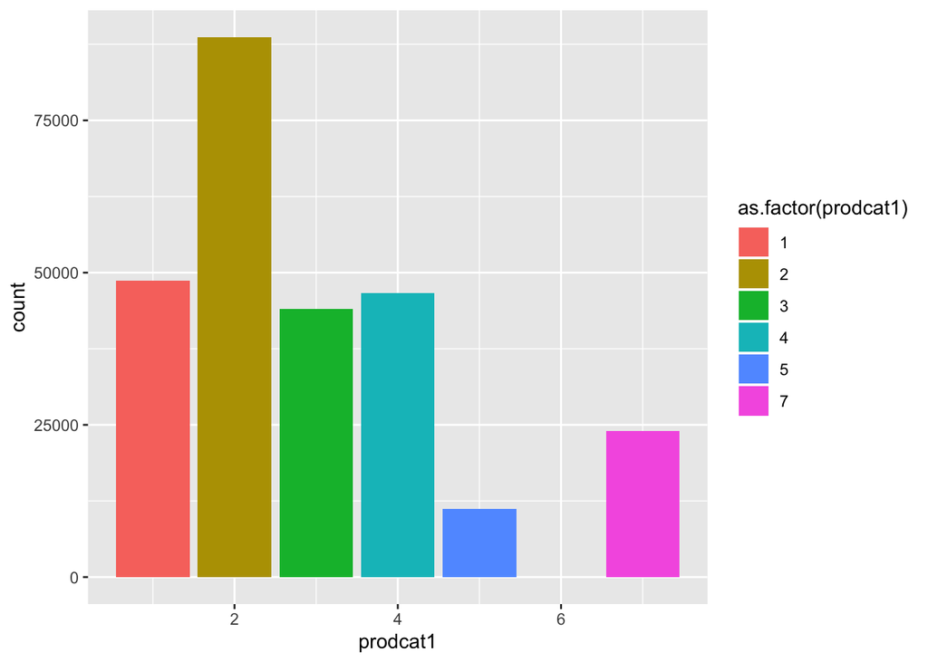

### –Column: revenue

Max revenue made from orders is **$150** and Min is **$0**  
**Average** made from order is **$74.94**  
**1st and 3rd Quartile range** are between **$37.43 and $112.28**

```
##    Min. 1st Qu.  Median    Mean 3rd Qu.    Max.
##    0.00   37.43   74.93   74.94  112.28  150.00
```

## *Online DataFrame*

From the Online Dataframe we can observe 7 variables

```
##     session           visitor                         dt
##  Min.   :      2   Min.   :     1   2016-03-28 07:16:46:     4
##  1st Qu.: 955436   1st Qu.:125528   2016-11-08 16:58:22:     4
##  Median :1903075   Median :252901   2017-11-05 16:32:08:     4
##  Mean   :1893075   Mean   :246963   2016-01-02 19:36:55:     3
##  3rd Qu.:2845886   3rd Qu.:377563   2016-01-31 18:19:14:     3
##  Max.   :3750761   Max.   :505850   2016-02-14 10:10:49:     3
##                                     (Other)            :954753
##      custno         category         event1           event2
##  Min.   :    6   Min.   :1.000   Min.   : 1.0     Min.   : 1.000
##  1st Qu.:17985   1st Qu.:2.000   1st Qu.: 1.0     1st Qu.: 4.000
##  Median :38040   Median :3.000   Median : 4.0     Median : 7.000
##  Mean   :37012   Mean   :2.685   Mean   : 4.5     Mean   : 5.667
##  3rd Qu.:56516   3rd Qu.:3.000   3rd Qu.: 7.0     3rd Qu.: 7.000
##  Max.   :71427   Max.   :3.000   Max.   :11.0     Max.   :10.000
##                                  NA's   :789846
```

### –Column: session

Highest count of sessions observed is **5** from **session_id72733**  
`Frequency Table`

```
##   72733  157423  161973  692928  811699 1178030
##       5       5       5       5       5       5
```

Lowest count of sessions observed is **1**  
`Frequency Table`

```
##
##  2  3  6 10 21 31
##  1  1  1  1  1  1
```

```r
# Total unique number of sessions
length(unique(df_online$session))
```

```
## [1] 850235
```

### –Column: visitor

```r
# Total unique number of visitors
length(unique(df_online$visitor))
```

```
## [1] 259950
```

*Lowest count* of visitors are **1** with *Max count* at **440** visits from **visitor_ID328620**  
`Frequency Table`

```
## 328620 178635 227902  53505 279881 328827
##    440    310    281    276    276    254
```

```
##
##  1  9 21 25 29 34
##  1  1  1  1  1  1
```

### –Column: dt

First date time observed **2016-01-01 00:00:08**  
Last date time observed **2017-12-31 23:58:05**

```
##                  Min.               1st Qu.                Median
## "2016-01-01 00:00:08" "2016-07-25 15:01:06" "2016-12-27 07:21:38"
##                  Mean               3rd Qu.                  Max.
## "2017-01-10 19:15:08" "2017-07-10 18:51:39" "2017-12-31 23:58:05"
```

### –Column: custno

```r
# Total unique number of customer number
length(unique(df_online$custno))
```

```
## [1] 57584
```

**cust_no713** is observed to have the highest counts at **855** **cust_no15** is observed to have lowest count at **1**  
`Frequency Table`

[output not shown]

```
##
##  15  28  59  94  96 116
##   1   1   1   1   1   1
```

### –Column: category

**Category 3** has highest browsing count at **706920**  
Followed by **category 2** with **194890** counts  
**category 1** has least count of browsings with **52964**

```
##
##      1      2      3
##  52964 194890 706920
```

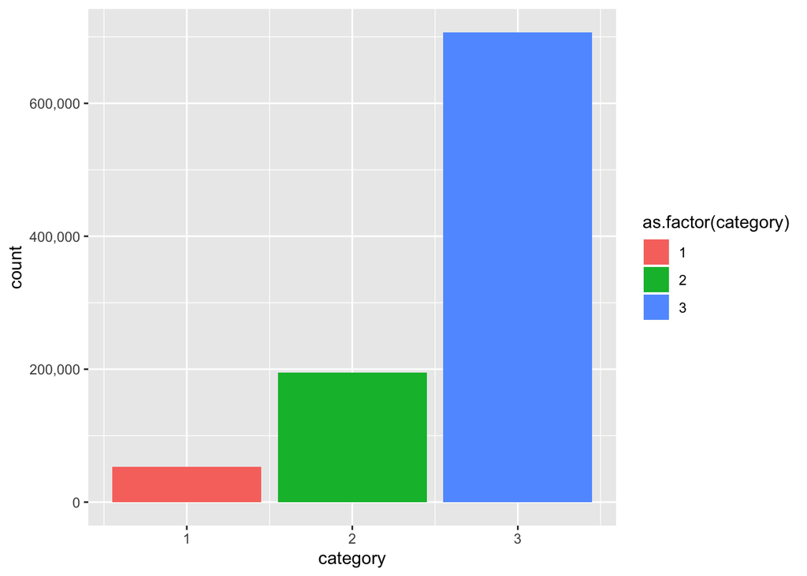

### –Column: event1

```
##    Min. 1st Qu.  Median    Mean 3rd Qu.    Max.    NA's
##     1.0     1.0     4.0     4.5     7.0    11.0  789846
```

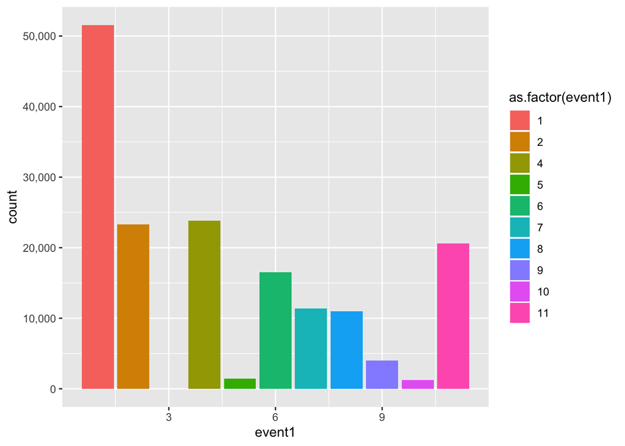

### –Column: event2

```r
# Total unique event2 types
length(unique(df_online$event2))
```

```
## [1] 10
```

For event2 **value 7** has the highest counts at **367857** counts  
For event2 **value 10** has the lowest count at **8235** counts

```
##    Min. 1st Qu.  Median    Mean 3rd Qu.    Max.
##   1.000   4.000   7.000   5.667   7.000  10.000
```

```
##
##      1      2      3      4      5      6      7      8      9     10
##  86496  15419 129795  94230  48282  29913 367857 122402  52145   8235
```

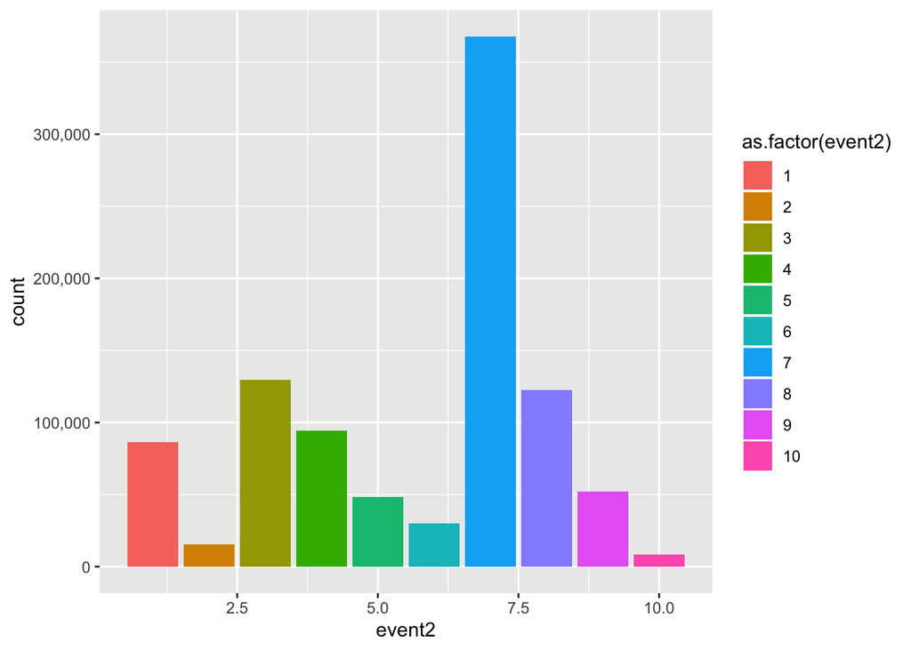

# **Feature Engineering and Feature Selection**

### Starting with fresh data set (after data exploration and design notes)

```r
rm(list = ls())
df_order =read.csv("data/order.csv", header = TRUE, sep = ",")
df_order <- df_order[df_order$prodcat1 %in% c(1,2,3),]
df_online = read.csv("data/online.csv", header = TRUE, sep = ",")
```

### Transforming data for feature selection, processing and merging

```r
# simplfying order by key
df_order$count <- 1
new_order <- aggregate(cbind(count) ~ custno + prodcat1, data = df_order, FUN = sum)

# simplfying online by key
df_online$count <- 1
df_online$event2 <- as.character(df_online$event2)

new_online <- aggregate(cbind(count) ~ custno + category + event2, data = df_online, FUN = sum)
new_online$event2 <- paste0("event_", new_online$event2)

# Feature transformation
new_online <- dcast(new_online, custno + category ~ event2, FUN = sum)
new_online[ is.na( new_online ) ] <- 0


names(new_order) <- c("custno", "category", "purchase_count")

# Merging data (only including order data)
main_df <- merge(new_order, new_online, by = c("custno", "category"), all.x = TRUE)

# QA
dim(main_df)
```

```
## [1] 66115    13
```

```r
dim(new_order)
```

```
## [1] 66115     3
```

```r
head(main_df)
```

```
##   custno category purchase_count event_1 event_10 event_2 event_3 event_4
## 1      1        1              1      NA       NA      NA      NA      NA
## 2      2        1              5      NA       NA      NA      NA      NA
## 3      3        1              6      NA       NA      NA      NA      NA
## 4      4        1              7      NA       NA      NA      NA      NA
## 5      5        1              1      NA       NA      NA      NA      NA
## 6      6        2              4       0        0       0       0       0
##   event_5 event_6 event_7 event_8 event_9
## 1      NA      NA      NA      NA      NA
## 2      NA      NA      NA      NA      NA
## 3      NA      NA      NA      NA      NA
## 4      NA      NA      NA      NA      NA
## 5      NA      NA      NA      NA      NA
## 6       0       0       2       1       1
```

### cleaning up column names and removing NA from data

```r
main_df <-main_df[, c("custno", "category", "purchase_count", paste0("event_", as.character(seq(10))))]
main_df[is.na(main_df)] <- 0
```

# **Model Design & Sampling**

### Create Test and Train Datasets

```r
# setting up sample test and training
sample_d <- sample(seq(nrow(main_df)),  size= nrow(main_df)*.8, replace = FALSE)

train_df <- main_df[sample_d, c("category", paste0("event_", as.character(seq(10))))]
test_df <- main_df[-sample_d, c("category", paste0("event_", as.character(seq(10))))]
```

```r
# Test and prediction result
multi_log_reg <- multinom(category ~ ., data = train_df)
prediction_values <-predict(multi_log_reg, test_df[, c(paste0("event_", as.character(seq(10))))]) %>%
   as.character() %>% as.numeric()
summary(multi_log_reg)
```

```
## Call:
## multinom(formula = category ~ ., data = train_df)
##
## Coefficients:
##   (Intercept)    event_1    event_2    event_3    event_4   event_5
## 2   0.2766119  0.3092549  0.7098480 -0.1901332 0.04315901 0.6022454
## 3  -0.7279871 -0.1779520 -0.5366298  0.3996829 0.11969967 0.4182317
##     event_6   event_7      event_8    event_9   event_10
## 2 0.3217355 0.2580019 0.0001240867 -0.1470421  0.3063126
## 3 0.5252020 0.3554742 0.4891467802  0.4028290 -0.1918335
##
## Std. Errors:
##   (Intercept)    event_1    event_2    event_3    event_4    event_5
## 2  0.01167508 0.02719269 0.07466476 0.03249301 0.03239440 0.04996337
## 3  0.01476918 0.03059674 0.08814750 0.03164281 0.03319778 0.05312214
##      event_6    event_7    event_8    event_9   event_10
## 2 0.07268412 0.01511517 0.03274056 0.04881819 0.07432037
## 3 0.07432425 0.01549159 0.03262515 0.04795721 0.08374028
##
## Residual Deviance: 97435.01
## AIC: 97479.01
```

# **Model Evaluation**

```r
#Counts Classified Incorrectly vs Correctly
performance <- table(prediction_values == test_df$category)
performance
```

```
##
## FALSE  TRUE
##  5865  7358
```

```r
#Accuracy Percentage
performance[2]/nrow(test_df) * 100
```

```
##     TRUE
## 55.64547
```

# **Summary of results**

From the Order Dataframe I normalized order in order to quanitfy the orders by customer and category. From the Online Dataframe I normalized the event2 variable to featurize the variable Using these two new datasets I have transformed I then merge both datasets on ‘custno’ and ‘category’. During my transformations and model building, I dropped the rows were product category was not 1, 2, or 3, from our order dataset. This was due there being no online.data for these product categories. This is how I reached my master dataset I would use to build my test and train samples.

In order to predict the category a customer is to make a purchase from I created a dataset which contained the quanity of the category purchased, quantified the number of times event2 occured, category user browsed, and customerID number. A multinomial logistic regression is like a logistic regression but for classification tasks of two or more, which is ideal for my challenge.